# Collective Layoffs and Offshoring: A Social Contract Account

Converted from PDF `Granulo-CollectiveLayoffsOffshoring-2025-JCR.pdf` · 21 pages · anchors: page `#pN`, block `#pN-bK`

Page 1

## **Collective Layoffs and Offshoring: A Social Contract Account**

ARMIN GRANULO ANNE-MADELEINE KRANZBÜHLER CHRISTOPH FUCHS STEFANO PUNTONI

Collective layoffs can occur for many reasons, often related to a firm’s pursuit of greater efficiency and cost reduction, and they tend to trigger negative reactions among the public. Anecdotal evidence suggests that offshoring, one of the most con troversial and politicized aspects of globalization, evokes particularly negative reac tions. We propose a social contract account of consumer reactions to collective layoffs and demonstrate differential consumer responses to collective layoffs due to offshoring versus other reasons, such as automation. Layoffs due to offshoring are perceived as an especially egregious violation of the normative expectation that firms should support members of their society. Data from nine experimental studies (*N*¼ 5,568; seven reported in the main paper and two in the General Discussion section), public con sumer responses to layoffs in a large online community (*N*¼ 29,045), and layoff announcements in the European Union (*N*¼ 1,261) show that consumers react more negatively to collective layoffs due to offshoring compared to other reasons. Supporting our social contract account, the negative effect of offshoring is stronger when offshoring affects workers in the consumers’ home (vs. foreign) country, when the firm is domestic (vs. foreign), and when most customers are domestic (vs. foreign).

*Keywords*: layoffs, social contracts, social contract violation, offshoring, interna tional marketing

ollective layoffs, where firms simultaneously termi nate the employment of a group of workers, are a common phenomenon (Datta et al. 2010). These layoffs can occur for various reasons, often driven by a firm’s pur suit of greater efficiency and cost reduction. One common reason is offshoring, which involves moving domestic pro duction and service jobs abroad (Kotabe and Mudambi 2009). Other reasons include leveraging technology to automate tasks and outsourcing work to specialized firms. Although all these approaches displace local labor, their public perception and perceived legitimacy may differ. Collective layoffs due to offshoring appear to elicit particu larly strong reactions from consumers and the general pub lic, even when other labor market forces, especially automation, have more significant overall effects on employment (Frey 2019; Rodrik 2018). For example, firms’ offshoring decisions have been shown to affect vot ing behavior substantially more than other collective layoff decisions (Margalit 2011). Offshoring firms have also been criticized in US presidential campaigns by both

Armin Granulo (armin.granulo@tum.de) is a postdoc in marketing, TUM School of Management, Technical University of Munich, Munich, Germany. Anne-Madeleine Kranzbu¨hler (anne.kranzbuhler@brand- university.de) is professor of customer experience, Brand University of Applied Sciences, Hamburg, Germany. Christoph Fuchs (christoph. fuchs@univie.ac.at) is professor of marketing at the Faculty of Business, Economics, and Statistics, University of Vienna, Vienna, Austria. Stefano Puntoni (puntoni@wharton.upenn.edu) is the Sebastian S. Kresge Professor of Marketing at The Wharton School, University of Pennsylvania, Philadelphia, PA, USA. Please address correspondence to Armin Granulo. The authors thank Peeter Verlegh and Balachandar Kaliappan for their helpful feedback. Supplementary materials are included in the web appendix accompanying the online version of this article. This manuscript is based on part of the lead author’s dissertation completed under the supervision of the third author.

*Klaus Wertenbroch served as associate editor during two rounds of review but recused himself after developing a conflict of interest with one of the authors and was not involved in the review process on subsequent rounds.*

*Editor: Bernd Schmitt*

*Associate Editor: Klaus Wertenbroch*

*Advance Access publication January 21, 2025*

© The Author(s) 2025. Published by Oxford University Press on behalf of Journal of Consumer Research, Inc. This is an Open Access article distributed under the terms of the Creative Commons Attribution License (https://creativecommons.org/licenses/by/4.0/), which permits unrestricted reuse,

distribution, and reproduction in any medium, provided the original work is properly cited. Vol. 00 2025

https://doi.org/10.1093/jcr/ucaf001

1

Page 2

Democratic and Republican candidates (e.g., Barack Obama and Donald Trump); former US president Joe Biden even proposed a “Biden Offshoring Tax Penalty” (Biden 2020).

Despite the practical and societal importance of this phe nomenon, it remains unclear what drives consumer reac tions to collective layoffs and whether such reactions differ systematically as a function of the efficiency-enhancing strategy adopted by firms (e.g., offshoring or other forms such as automation). Prior research has thus far provided initial evidence that consumers react negatively to offshor ing (Grappi, Romani, and Bagozzi 2013; Thelen, Yoo, and Magnini 2011; Whitaker, Krishnan, and Fornell 2006). For example, prior research has investigated consumer percep tions of service quality when firms offshore versus do not offshore their customer service (Whitaker et al. 2006), and how consumers react when firms offshore versus do not offshore production (Grappi et al. 2013). However, these studies were not designed to disentangle negative consumer responses to offshoring from negative consumer responses to layoffs in general (for a systematic literature review, see table A1 in web appendix A). What makes moving domes tic work abroad psychologically different from other col lective layoff reasons, such as automating or outsourcing work, even if they involve comparable reductions of the domestic labor force? And if consumers indeed react more negatively to offshoring than to other layoff decisions, how do these differential reactions vary depending on firm and consumer characteristics?

We seek to address these gaps by (i) proposing and test ing a comprehensive theoretical account of psychological reactions to collective layoffs; (ii) documenting negative consumer reactions to layoffs resulting from offshoring versus other reasons, both in real-world settings and con trolled experiments holding constant the number of domes tic job losses; and (iii) demonstrating that our findings extend beyond, and are poorly explained by, previously proposed explanations, such as ethnocentrism, patriotism, or product quality perceptions. Specifically, we theorize that consumer reactions to collective layoffs can be under stood within a *framework of social contracts*. Social con tracts delineate implicit and reciprocal (“give-and-take”) relationships between firms and members of their society, such as consumers or workers (Donaldson 1982; Dunfee, Smith, and Ross 1999). We propose that consumers react more negatively to decisions about offshoring compared to other firm decisions that involve collective layoffs, such as automation. This is because offshoring uniquely breaches a key element of social contracts: the normative expectation that firms should support members of their society by pro moting and committing to local production. Our theory identifies important moderators of negative consumer reac tions to offshoring, including the location of (i) the collec tive layoffs, (ii) the firm’s headquarters (HQ), and (iii) the firm’s customer base. To test our predictions, we employ a

multi-method approach, incorporating both field and labo ratory data. Our studies compare the effect of offshoring against several other forms of collective layoffs, including automation, outsourcing, relocation, and declining demand.

Our research makes three main contributions. First, we contribute to the vast literature in marketing, management, finance, and other disciplines on the phenomenon of off shoring (Bretscher 2023; Farrell 2005; Thelen et al. 2011) by unraveling the psychology of offshoring and its conse quences for consumer attitudes and behavior. Our social contract framework provides a more comprehensive con ceptualization of consumer responses to collective layoffs than previously proposed accounts and provides novel insights particularly relevant to the international marketing literature. For example, our framework predicts that in the context of offshoring, consumers perceive domestic firms more negatively than foreign firms, which represents a reversal of the well-documented tendency for consumers to favor (products from) domestic over foreign firms (Sharma 2011; Verlegh 2007). Second, our research advances the literature on social contracts in marketing, management, and business ethics (Malhotra, Sahadev, and Purani 2017; Montgomery et al. 2018; Neiman 2013). We show that social contract theory can serve as a fruitful framework to explain consumer reac tions to firm actions that affect members of their society (e.g., workers). We also provide new insights into the for mation of social contracts, an understudied aspect in social contract theory (Thompson and Hart 2006) and in market ing research (Montgomery et al. 2018). These new insights may inform phenomena beyond offshoring; for instance, consumer reactions to brand transgressions may depend on antecedents on both the firm level (e.g., the location of the firm’s HQ) and the community level (e.g., the location of the firm’s customer base).

Third, our research contributes to the field of lay eco nomics, which studies how lay people think about the workings of the economy (Bhattacharjee, Dana, and Baron 2017; Boyer and Petersen 2017). Specifically, our work sheds light on how consumers perceive the causes of col lective layoffs, often related to a firm’s pursuit of greater efficiency and cost reduction. Understanding these percep tions is critical, as they shape political beliefs and policy responses (Boyer and Petersen 2017), yet this area remains underexplored in lay economics. For instance, two primary forces shaping this quest for efficiency are globalization and technology, of which offshoring and automation are the most visible manifestations. Our social contract account offers a deeper understanding of why consumers react dif ferently to layoffs caused by offshoring versus automation. Consumers tend to view offshoring as a more severe breach of the reciprocal relationship inherent in the social contract, perceiving it as less legitimate behavior than automation, even when the impact on local employment is similar. In

2 JOURNAL OF CONSUMER RESEARCH

Page 3

the next section, we review relevant related literature and provide the conceptual background for our predictions.

#### **CONCEPTUAL DEVELOPMENT**

Collective layoffs are a widespread and significant organizational practice (Datta et al. 2010). In response to intense competitive pressure, firms often rely on collective layoffs as a strategy to boost efficiency and cut costs. To achieve these goals, firms may adopt various strategies. For instance, firms can reduce their production costs by outsourcing labor to specialized firms within the same country (Goldschmidt and Schmieder 2017) or by replacing human labor with machines (Acemoglu and Restrepo 2020). A major efficiency-enhancing strategy that has received considerable attention from both academics and practi tioners is offshoring (Contractor et al. 2010)—moving domestic labor abroad (Brown and Siegel 2004). A large body of research has documented positive effects of off shoring on individual firms; for example, offshoring can help firms to become more efficient (Farrell 2005), more innovative (Nieto and Rodrıguez 2011), and more globally competitive (Di Gregorio, Musteen, and Thomas 2009). Moreover, offshoring can help mitigate global inequality by offering better earning opportunities to workers in developing countries (Rodrik 2018).

At the same time, research in services marketing sug gests that firms may encounter negative consumer reactions when they offshore their customer service to another coun try (Bharadwaj and Roggeveen 2008; Durvasula and Lysonski 2008; Thelen et al. 2011). For example, consum ers may perceive call centers less positively when they are offshored to a foreign country than when they are located domestically because they are concerned about a decline in service quality (Bharadwaj and Roggeveen 2008). Consumers may oppose service offshoring because of free trade resentment and foreign worker enmity (Thelen et al. 2011) or because they consider it unpatriotic (Durvasula and Lysonski 2008). Most relevant to the present investiga tion, Grappi et al. (2013) examined how firms’ decisions to offshore versus maintain corporate activities at home affect consumer attitudes toward firms. They find that laying off domestic workers to offshore jobs abroad makes firms be seen more negatively and as less moral (vs. firms that retain these functions in their home country). However, this line of research did not separate the effect of offshoring on firm perceptions from the general negativity associated with collective layoffs (St€abler et al. 2023; see table A1 in web appendix A). This separation is crucial because it remains uncertain whether consumer reactions would be equally negative in response to other reasons for collective layoffs, such as automation. To address this question, we introduce a new theoretical framework centering on social contract violations.

#### Social Contract Theory

Society operates not only on the basis of legal contracts but also of social contracts, which are implicit promises and agreements that parties are expected to adhere to (Donaldson 1982; Rawls 2009; Rousseau 1997). In contrast to legal contracts, social contracts are not enforceable or legally binding. Yet, this does not diminish their influence. In political philosophy, the concept of a social contract is a pivotal perspective for describing mutual expectations between people and authorities within a society (Hobbes 1998; Rawls 2009; Rousseau 1997). In a business context, the idea of social contracts has been applied to understand the reciprocal, normative expectations between firms and the society (Donaldson 1982; Dunfee et al. 1999). Social contracts can be construed at different hierarchical levels. At the broadest level, social contracts in a business setting may occur between business in an abstract, collective sense and the society in which they are embedded, encompassing the normative idea that firms in general have the right to operate in exchange for contributing positively to societal welfare (Donaldson 1982). At the industry level, social contracts may occur between specific industries and soci ety, with reciprocal expectations shaped by the industry’s role (Dunfee et al. 1999). For example, the healthcare industry faces unique ethical expectations due to its critical role in promoting public health (Leisinger 2005). Finally— and most relevant to our theorizing—social contracts may occur at the individual firm level. At this level, social con tracts describe reciprocal, normative obligations between individual firms and society. Specifically, we propose that two pillars of social contracts at the firm level—their soci etal dimension and their reciprocal dimension—provide a framework for understanding why and when consumers perceive collective layoffs due to offshoring (vs. other rea sons) to be a more severe social contract violation.

*Reciprocity.* Social contracts operate on the basis of reciprocity (Donaldson 1982; Dunfee et al. 1999)—sup porting others in return for the support received (Gouldner 1960; Molm 2010)—which is a cornerstone of human civi lization. Reciprocity influences how individuals interact with each other and sets expectations for them (Falk and Fischbacher 2006; Molm 2010; Trivers 1971), as well as how firms engage with their stakeholders. It is crucial in many economic settings, such as setting fair wages (Kahneman, Knetsch, and Thaler 1986). In the context of social contracts, the principle of reciprocity implies an implicit and mutual give-and-take obligation between firms and members of a given society, such as consumers. Unlike norms, such as injunctive or descriptive social norms (Cialdini, Reno, and Kallgren 1990), social contracts not only specify normative expectations of what society should do for firms or what firms should do for society, but also specify give-and-take relationship dynamics. For instance, consumers and workers should support firms by purchasing

GRANULO ET AL. 3

Page 4

their products and providing a skilled labor force; in return, firms are expected to support consumers and workers by enhancing consumer welfare, paying corporate taxes, and creating employment opportunities (Donaldson 1982).

*Society.* While social contracts involve reciprocal rela tionships, these relationships are not without boundaries. As many scholars have noted, social contracts have a natu ral boundary: they are generally understood to operate within the bounds of a particular society. For example, Donaldson (1982) defined a social contract in a business context as an implicit contract between firms and members of a given society (vs. a supra-national entity). In the mod ern world, society is typically defined at the level of the nation-state (Donaldson 1982; Harari 2014; Hsieh 2015; Rawls 2009). And, indeed, consumers perceive social con tracts to exist within countries, that is, they tend to be national in scope (Mead et al. 2024). Thus, even though the concept of society can take many forms, such as linguistic or ethnic communities, it is often linked with a common nationality (Anderson 2006; Gellner 2008). Extensive research demonstrates that feelings of national attachment are deeply embedded in people’s belief systems (Dalton 2021), significantly shape people’s self-concept (Huddy and Khatib 2007), and influence consumer behavior (Verlegh 2007). Accordingly, people tend to be more attached to their country, such as France, than their broader supra-national entities, such as the European Union, even if they might feel devoted to both (Dalton 2021). In line with this, we argue that the reciprocal obligations emanating from the social contract are, to an important extent, valid within the national context.

The concept of society within social contracts can encompass different constituents (Donaldson 1982; Hsieh 2015). Society typically refers to “all of us citizens” but can also encompass specific subgroups, such as workers of a particular firm (Dunfee et al. 1999). In this research, we focus on how citizens (consumers) respond to firms’ col lective layoff decisions, which harm a specific constituent of society (workers). We argue that such decisions—partic ularly when driven by offshoring—can lead consumers, even when not directly affected by the layoffs, to perceive a violation of the social contract. For instance, when con sumers learn that a firm has laid off domestic workers to relocate production overseas, they may develop more nega tive attitudes toward the firm, even if they have no direct connection to the affected workers. This, in turn, can reduce buying intentions and amplify consumer boycott intentions (Klein, Smith, and John 2004).

#### Collective Layoffs and Social Contract Violations

To fulfill their reciprocal obligations emanating from the social contract, firms are expected to create and maintain employment opportunities for members of their society

(Donaldson 1982; Hsieh 2015). We argue that collective layoffs due to offshoring represent a particularly strong violation of this reciprocal obligation. All collective layoffs reduce domestic employment opportunities and thus repre sent a violation of the social contract. However, offshoring-related layoffs not only reduce domestic employment opportunities but also move these opportuni ties to a foreign country, replacing jobs for local workers with jobs for foreign workers (e.g., replacing American workers with non-American workers). By offshoring, firms thus not only fail to uphold their end of the give-and-take relationship with members of their domestic society (pro viding domestic employment opportunities) but also “give” employment opportunities to members of a foreign society. Extensive research in related domains documents that such decisions—that is, benefitting another group at the expense of one’s own group—can evoke intense negative emotional reactions (Esses et al. 2001; King, Knight, and Hebl 2010; Shackelford and Buss 1996; Stefaniak, Mallett, and Wohl 2020). For instance, research on interpersonal relationships shows that giving expected benefits to parties outside of the focal relationship can evoke intense feelings of betrayal (Shackelford and Buss 1996). Research has also shown that individuals react negatively when others fail to fulfill their reciprocal obligations to their societal group. For instance, people are willing to punish those who do not reciprocate toward their group, even at a personal cost and even if they have not been directly harmed (Falk and Fischbacher 2006; Molm 2010).

Against this background, we argue that a decision that harms members of the domestic society and, at the same time, benefits members of a foreign society should lead to strong perceptions that a firm betrayed the reciprocal rela tionship emanating from the social contract. In contrast, other forms of collective layoffs, such as outsourcing or automation, should not have the same effect. The benefit for overseas workers at the cost of domestic workers should lead consumers to perceive offshoring as a particularly egregious violation of acceptable corporate behavior, resulting in more negative reactions toward firms that off shore. For example, consumer attitudes toward firms, which are a critical predictor of consumer boycotts (Klein, Smith, and John 2004), sales (Fazio and Petty 2008), and stock returns (Aaker and Jacobson 2001), should decrease more sharply in response to offshoring compared to other types of collective layoffs. Formally,

**H1:** Consumer reactions to collective layoff announcements are more negative in the case of offshoring, compared to other reasons for collective layoffs.

If perceived social contract violations underlie negative consumer reactions to offshoring, we should further expect that the magnitude of this effect depends on the strength of the social contract. In turn, the strength of the social con tract and the moral obligations resulting from it depend on

4 JOURNAL OF CONSUMER RESEARCH

Page 5

the give-and-take relationship between firms and society members (Donaldson 1982). Both firm-level and societal- level factors should therefore influence the severity of per ceived social contract breaches. Below, we theorize three such factors affecting the intensity of negative reactions to offshoring to assess the explanatory power of our social contract account. These factors, which center around the concept of “location,” are of both theoretical and manage rial relevance.

*Location of the Collective Layoffs.* Given that social contracts are conceptualized at the societal level (Donaldson 1982; Mead et al. 2024; Nussbaum 2004; Rawls 2009), consumers should perceive a stronger social contract with members of their own society (e.g., domestic workers) than with those of a different one. Consumers should thus perceive layoffs affecting overseas workers as a weaker violation of *their* social contract. We, therefore, argue that the extent to which a firm’s decision is perceived as a social contract violation should depend on whether it affects workers who are members of the same society (e.g., domestic workers) versus of a foreign society (e.g., foreign workers). Formally,

**H2:** Consumer reactions to collective layoffs due to offshor ing are more negative when the layoff location is domestic versus foreign.

*Location of the Firm’s HQ.* A large body of research documents that a firm’s country of origin, typically deter mined by the location of its HQ (Johansson, Douglas, and Nonaka 1985; Samiee, Shimp, and Sharma 2005), has important economic effects. For example, consumers prefer domestic products over foreign ones (Verlegh 2007); investors favor domestic assets over foreign ones (Chan, Covrig, and Ng 2005); and the share of domestic versus international trade of goods and services is much larger than what normative trade models would predict (Wolf 2000). Based on our social contract account, however, we posit that this positive bias toward firms from consumers’ home country (Sharma 2011; Verlegh 2007) should reverse in the context of collective layoffs due to offshoring. The conceptualization of social contracts as implicit, reciprocal agreements and expectations between consumers and firms within a given society not only implies that both the recip rocal and societal dimensions are central to these con tracts—but also that these two aspects are interrelated.

Specifically, the strength of the give-and-take relation ship (reciprocal dimension) should depend on whether the individual firm is a member of the same society as the con sumers (societal dimension). For example, US consumers should be more likely to regard US firms, that is, firms with corporate HQ in the United States, as members of the same society than foreign firms, that is, firms with HQ out side the United States. Consumers should believe that a firm from their society (i.e., a domestic firm) has greater

reciprocal obligations than firms from other societies (i.e., a foreign firm). This reasoning aligns with extensive litera ture showing that people’s reciprocal expectations depend on whether they share a common identity with others (e.g., a shared national identity; Balliet, Wu, and De Dreu 2014; Yamagishi and Kiyonari 2000). As a result, we theorize that consumers hold domestic firms to a higher standard than foreign firms when they violate the reciprocal obliga tion to support members of their domestic society; that is, consumers should react particularly negatively when a domestic (vs. foreign) firm lays off workers and relocates production to another country. Formally,

**H3:** Consumer reactions to collective layoffs due to offshor ing are more negative when the location of the firm’s head quarters is domestic versus foreign.

*Location of the Firm’s Customer Base.* Social contracts set expectations about how firms and members of their society should interact. Firms should support domestic workers, for example, by creating domestic jobs. In exchange, local consumers should also support domestic firms. The most common and easiest way to support a firm is to buy its goods or services (Guo, Gruen, and Tang 2017). If members of a society fail to fulfill this expecta tion, consumers should perceive the resulting social con tract as weaker. We therefore argue that firms’ perceived obligations emanating from the social contract should depend on the location of their customer base. If the major ity of customers are located outside of the focal country, the firm’s perceived social contract responsibilities should be less stringent. As a result, such a situation should be seen as a weaker violation of the social contract’s idea of reciprocity (Rousseau 1989), and consumers should regard offshoring as a less egregious social contract violation. Formally,

**H4:** Consumer reactions to collective layoffs due to offshor ing are more negative when most customers are domestic versus foreign.

#### **OVERVIEW OF STUDIES**

We organize the empirical section of this article into two main parts. In the first part (studies 1–3), we test our pre diction that collective layoffs, which harm individual mem bers of society (i.e., workers), lead to particularly negative consumer reactions when they result from offshoring com pared to other ways to increase efficiency, such as automa tion or outsourcing. To do so, we use lab and field data (e.g., online consumer responses, a dataset on collective layoffs in the European Union) and different operationali zations (e.g., consequential choice, attitudinal responses). In the second part (studies 4–6), we provide evidence for our social contract account. Drawing on the

GRANULO ET AL. 5

Page 6

conceptualization of social contracts as reciprocal obliga tions between individual firms and members of a given society (e.g., consumers), we experimentally manipulate important aspects of the social contract at the firm level (e.g., testing the role of the firm’s HQ location) and the consumer level (e.g., testing the role of the firm’s customer base location), investigate the underlying mechanism (e.g., testing for moderated mediation by consumers’ perceived social contract violations), and address alternative accounts (e.g., ethnocentrism, product quality). Details on the stimu lus materials and preregistrations can be found in web appendices B and C. All data are openly available at https://osf.io/9vjt5/.

#### **STUDY 1: CONSEQUENTIAL CHOICE**

We start our empirical investigation with a series of studies examining whether consumer reactions are more negative when collective layoffs are related to offshoring as opposed to other causes (hypothesis 1). We first present evidence for this prediction from two controlled experi ments (studies 1 and 2). Subsequently, we offer comple mentary real-world evidence that aligns with our experimental findings (studies 3A and 3B), thus providing further suggestive evidence for the robustness and general izability of our main effect prediction.

Study 1 is a consequential choice experiment to test whether consumers choose a brand less when it lays off workers due to offshoring versus automation. Offshoring and automation, which both can replace domestic labor, are among the most important strategies for increasing opera tional efficiency (Rodrik 2018), can affect workers with similar skill sets, and are frequently in direct competition with one another (with automation becoming increasingly important; Frey 2019). The study was preregistered (https://aspredicted.org/c4kz-vhym.pdf).

#### Method

We recruited 807 US consumers (*M*age ¼ 41 years, 54% females) via the online panel Amazon Mechanical Turk (MTurk) who were randomly assigned to one of two condi tions using a consequential choice design (for similar designs, see Meyvis and Van Osselaer 2018). Participants were introduced to two US brands that manufacture and sell socks and were told that they could win a $25 voucher for the brand they preferred. Participants were exposed to both brands—Feat. Sock Co. and New Socks—side by side and were provided with exemplary pictures of products and information about each brand (the socks displayed were real products; web appendix B). We manipulated between participants whether one of the brands (i.e., Feat. Sock Co.) laid off workers due to offshoring versus automation, while the other brand (i.e., New Socks) served as a control brand.

In the offshoring condition, participants read that the tar get (i.e., manipulated) brand had recently decided to move its production from the United States and now relied on foreign workers. Participants in the automation condition read instead that the same brand had recently decided to keep its factory in the United States and now relied on machines. In both conditions, participants were informed that the brand had laid off 475 workers in their US plant. To describe the control brand, participants read that the brand recently decided to change its customer service and now offered self-service options to resolve customer requests. We randomized whether the offshoring (vs. auto mation) brand or the control brand was presented first. We then measured product choice for the offshoring (vs. auto mation) brand versus the control brand, which served as our dependent variable. Upon study completion, we con ducted a lottery, awarding an online shopping voucher to a randomly determined winner. After data collection was completed, the winning participant received the voucher, and all participants were debriefed.

#### Results

When the target brand’s layoffs were due to offshoring, only 11.7% of the participants chose it (88.3% chose the control brand). In contrast, when the layoffs were due to automation, 26.2% of the participants chose its product (73.8% chose the control brand; χ<sup>2</sup>(1) ¼ 27.89, *p <* .001). Thus, as preregistered, information that collective layoffs were due to offshoring (vs. automation) resulted in a signif icant 14.5% decrease in choice share (*Z* ¼ −5.28, *p <* .001). A logistic regression with choice as the dependent variable, experimental condition as the independent varia ble, and order of brand presentation, gender, age, and study completion time as covariates produced consistent results; that is, collective layoffs due to offshoring (vs. automation) significantly reduced the participants’ propensity to choose the brand (*b* ¼ −1.030, *p <* .001, CI95% [−1.41, −0.65]). To the best of our knowledge, study 1 thus provides the first (causal) evidence for the negative effect of offshoring on consumer behavior (hypothesis 1).

#### **STUDY 2: GENERALIZABILITY OF THE**

#### **MAIN EFFECT**

Study 2 aims to provide additional supporting evidence for the negative impact of offshoring on consumer reac tions (hypothesis 1) by using different control conditions, context, dependent variables, and samples. Specifically, we examine whether consumer reactions to collective layoff announcements due to offshoring are more negative com pared to those due to outsourcing (where production is transferred to another firm within the same country) or relocation (where production is transferred within the same firm and the same country). Compared to study 1, we

6 JOURNAL OF CONSUMER RESEARCH

Page 7

sampled consumers from a different country (United Kingdom vs. United States). We presented participants with a media article about a layoff announcement, experi mentally varied the justification provided in the article for the layoff decision, and asked them to rate their firm atti tude. The study was preregistered (https://aspredicted.org/ bfqc-k77k.pdf).

#### Method

We recruited 601 UK consumers (*M*age ¼ 35 years, 65% female; Prolific) and randomly assigned them to one of three conditions (collective layoff reason: offshoring vs. outsourcing vs. relocation) using a between-participants design. All participants read a newspaper article that intro duced the fictitious UK firm Magan’s, a large manufacturer of seeds and other gardening products, and provided further details on the firm, including its founding year, number of employees, and annual revenue (for full text, see web appendix B). In all conditions, participants read that the UK-based firm had announced that it would shut down its main production plant in Manchester and lay off 4,000 workers in order to become more efficient. In the offshor ing condition, participants read that the firm would open a new factory abroad, and thus production would move to a foreign country. In the outsourcing and relocation condi tions, participants read that the firm would instead hire a contractor in the United Kingdom or open a new factory in the United Kingdom, respectively, thus production would remain in the United Kingdom. Next, participants indicated their attitude toward the firm using an established seven- point scale (Becker-Olsen 2003; “My overall impression of the firm described is. . . ‘bad/good’, ‘unfavorable/favor able’, ‘negative/positive’”; α ¼ 0.94).

#### Results

A one-way ANOVA on attitude toward the firm revealed significant differences across conditions (*F*(2, 598) ¼ 33.02, *p <* .001, η<sup>2</sup>¼ 0.10, CI95% ¼ [0.06, 0.14]). Participants rated the firm more negatively when collective layoffs were due to offshoring (*M*offsh. ¼ 2.75, SD ¼ 1.31) compared to when they were due to outsourcing (*M*outs. ¼ 3.46, SD ¼ 1.23; *t*(598) ¼ −5.57, *p <* .001, *d* ¼ −0.56, CI95% ¼ [−0.76, −0.36]) or due to relocation (*M*reloc. ¼ 3.76, SD ¼ 1.28; *t*(598) ¼ −7.91, *p <* .001, *d* ¼ −0.78, CI95% ¼ [−0.98, −0.57]). As a side finding, we found that participants rated the firm significantly more negatively when collective layoffs were caused by outsourcing versus relocation (*t*(598) ¼ −2.34, *p* ¼ .020, *d* ¼ −0.24, CI95% ¼ [−0.43, −0.04]). In sum, the results of study 2 provide con verging evidence for the distinct effect of offshoring on consumer attitudes.

#### **STUDIES 3A AND 3B: COMPLEMENTARY**

#### **FIELD EVIDENCE**

Studies 3A and 3B aim to complement studies 1 and 2 by offering corroborating field evidence for our prediction that collective layoffs elicit more negative responses when they are linked to offshoring (vs. other causes; hypothesis 1). In both studies, we rely on secondary (correlational) data from different sources—user-generated content and press releases—and analyze the sentiments in these data as a proxy variable for consumers’ reactions to offshoring using a sentiment analysis algorithm. This type of senti ment analysis method has been identified as a valid method to extract consumer attitudes from digital content (Schmitt 2019).

#### Study 3A

For study 3A, we collected data on public consumer responses to layoffs from Reddit, one of the world’s largest and most active online communities (Lebrous 2017). We tested whether user commentary is more negative when layoffs are related to offshoring than when they are related to automation. We preregistered the web scraper’s Python code, hypothesis, data collection procedure, and data analy sis plan (https://aspredicted.org/9zp4-422q.pdf).

*Method.* To collect data on public consumer reactions to layoffs, we scraped Reddit discussions related to layoffs resulting from offshoring and automation (Boegershausen et al. 2022). On Reddit, users can post content (such as text or a link) within online forums covering a wide range of topics, and other users can comment on the original post.

To identify Reddit posts related to layoffs due to offshor ing versus automation, we wrote a code that searched for posts containing a set of pre-specified terms (all search terms were preregistered and paralleled for offshoring and automation; web appendix C). For example, we searched for posts that included terms such as “offshoring” and “layoff” or “automation” and “layoff.” This search process resulted in an initial dataset of 1,046 Reddit posts (*N*offsh. ¼ 328; *N*autom. ¼ 718). Following preregistered procedures and criteria, two research assistants, blind to the research question, independently assessed whether each Reddit post in this corpus was indeed related to layoffs due to offshor ing or automation (web appendix C). For example, several of the offshoring posts in the initial dataset were excluded because they referred to offshoring in the energy (offshore oil production) or financial sectors (offshore bank accounts). The final dataset consisted of 674 Reddit posts, out of which 480 contained at least one user comment (*N*offsh. ¼ 36; *N*autom. ¼ 444). Next, we scraped all user comments for each of the identified Reddit posts using PRAW, a Reddit API wrapper, resulting in a dataset of 29,045 comments (*N*offsh. ¼ 1,309; *N*autom. ¼ 27,736). We created a dummy variable to indicate whether the Reddit

GRANULO ET AL. 7

Page 8

comment pertained to layoffs resulting from offshoring or automation, which served as our independent variable.

To measure the valence of these comments, we extracted a sentiment score from each comment using a popular sen timent analysis algorithm called Valence Aware Dictionary and sEntiment Reasoner (VADER; Hutto and Gilbert 2014). The sentiment score indicates how negative or posi tive the sentiment of each Reddit comment related to lay offs due to offshoring and automation was (ranging from 1 to þ1) and served as our dependent variable.

*Results.* Our dataset of Reddit comments involves a hierarchical data structure. Each comment (*N* ¼ 29,045; level 1) is nested in a Reddit post (*N* ¼ 480; level 2). As preregistered, we, therefore, conducted a linear multilevel regression model of the Reddit comments’ sentiment score (level 1) on a dummy variable capturing whether the Reddit comments were related to layoffs due to offshoring or automation, with Reddit posts as random effects (level 2). In support of our hypothesis, this analysis revealed that Reddit comments had a significantly lower sentiment score when they were associated with offshoring-related layoffs than automation-related layoffs (model 1: *b* ¼ −0.071, *p* ¼ .011, CI95% ¼ [−0.13, −0.02]; table 1). Based on the esti mated fixed effects, the multilevel model predicts that Reddit comments have a mean sentiment score of 0.124 when layoffs were related to automation (see intercept of model 1) and of 0.053 when layoffs were related to offshor ing (*b* ¼ −0.071), a 58% decrease in valence.

Across all these models, we found a significant and neg ative coefficient for offshoring (model 2: *b* ¼ −0.066, *p* ¼ .014, CI95% ¼ [−0.12, −0.01]; model 3: *b* ¼ −0.066, *p* ¼ .014, CI95% ¼ [−0.12, −0.01]; model 4: *b* ¼ −0.061, *p* ¼ .031, CI95% ¼ [−0.12, −0.01]; model 5: *b* ¼ −0.061, *p* ¼ 0.031, CI95% ¼ [−0.12, −0.01]). That is, including covariates of comment-specific characteristics and random effects at different levels of our hierarchical data structure,

**TABLE 1**

STUDY 3A RESULTS

[output not shown]

NOTE: table converted from PDF layout to HTML text; cell boundaries are reconstructed. See PDF if exact alignment matters.

NOTES.—*N* ¼ 29,045. Standard errors are in parentheses. aOffshoring dummy is to be interpreted as relative differences to the category automation. bMeasured in units of 50. *p <* .01. *p <* .05.

8 JOURNAL OF CONSUMER RESEARCH

Page 9

we consistently find that the estimated sentiment of Reddit comments is significantly more negative when they are related to layoffs resulting from offshoring (vs. automa tion). Next, we examined the possibility that the effect is not driven by offshoring generating negative reactions among consumers, as we predicted, but rather by automa tion generating especially positive reactions (e.g., the inter cept in model 1 was positive; table 1). To explore this potential alternative explanation, we scraped a random sample of 1,046 Reddit posts (matching the originally pre registered number of Reddit posts) and scraped their user comments (see web appendix D for the code). We then compared the sentiment of these randomly selected control comments with the sentiment of the comments related to automation and offshoring. A linear multilevel regression model (level 2: Reddit post) revealed that the comments on the random posts were significantly more positive than both the comments on posts about offshoring (*b* ¼ −0.141, *p <* .001, CI95% ¼ [−0.20, −0.08]) and automation (*b* ¼ −0.066, *p <* .001, CI95% ¼ [−0.09, −0.04]).

We repeated this analysis with the same four model specifications depicted in table 1 and obtained consistent results for comments related to offshoring (all *p*s *<* .001) and automation (all *p*s *<* .001). These analyses speak against the possibility that the results are driven by Reddit users’ potential positivity toward automation. Overall, study 3A provides real-world evidence from observational data supporting the notion that layoffs related to offshoring elicit more negative consumer responses than those related to automation.

#### Study 3B

In study 3B, we tested the hypothesized negative effect of layoffs resulting from offshoring using a similar approach as in study 3A but a different data source. Specifically, we assembled a comprehensive dataset on European collective layoffs that allowed us to assess whether firms’ collective layoff announcements receive more negative media coverage when they result from off shoring than when they result from the decision to relocate or outsource production within the same country. Consistent with studies in communications research, we use media coverage as a proxy for consumer sentiment (Erikson and Tedin 2015; Hopkins, Kim, and Kim 2017). Previous research has demonstrated that media coverage, to an important extent, reflects public opinion (Haller and Norpoth 1997; Soroka, Stecula, and Wlezien 2015). For instance, Hopkins et al. (2017) suggest that newspaper cov erage reflects consumer sentiment about the economy.

*Method.* We analyzed press coverage of collective lay off announcements, utilizing data from the European Monitoring Center of Change (EMCC; Eurofound 2018), which maintains a database documenting collective layoff announcements that occurred across all European Union

countries from 2002 to 2018, comprising a total of 23,189 announcements (collective layoffs, according to the EMCC, involve the elimination of a minimum of 100 jobs, or impacting 10% of the workforce in sites with more than 250 people). The database includes information on the rea son behind the collective layoffs (e.g., offshoring), quanti tative details concerning the scale of the collective layoffs (e.g., the number of job losses announced), and text-based summaries of available media coverage on the collective layoffs (e.g., newspaper articles on why the layoffs occurred, on reactions of labor unions, and other conse quences of the announcement). These textual summaries are generated by Eurofound correspondents and are based on the content from a broad range of daily press and online sources (for a concrete example, see web appendix D).

To obtain data on collective layoffs involving firms either relocating production to another country or retaining production within the same country, we selected cases from this dataset that were attributed to (i) offshoring (i.e., layoffs where production is relocated to another country; *N* ¼ 881), (ii) outsourcing (i.e., layoffs where production is subcontracted to another company but remains in the same country; *N* ¼ 102), and (iii) relocation (i.e., layoffs where production remains in the same company and the same country; *N* ¼ 278). We created dummy variables to capture whether the firms’ collective layoff was due to offshoring, outsourcing, or relocation, which served as our independent variables. It is important to note that outsourcing and relo cation may elicit perceptions of social contract violations within the immediate community. However, we contend that these negative reactions should be more intense and widespread in the case of offshoring. We measured the valence and intensity of the reactions to these three types of collective layoffs using the same method as in study 3A. That is, we extracted a sentiment score from the (textual) media coverage summary of each collective layoff event using VADER. The sentiment score indicates how negative or positive the sentiment of the media coverage of each lay off case was (ranging from 1 to þ1) and served as our dependent variable.

*Results.* The sentiment score of media coverage, our proxy for the valence of public reactions to collective lay offs, was significantly more negative when the firms’ col lective layoffs were due to offshoring (*M* ¼ −0.11, SD ¼ 0.50) than when they were due to outsourcing (*M* ¼ 0.06, SD ¼ 0.53; *t*(981) ¼ −3.21, *p* ¼ .001, *d*¼−0.34, CI95% ¼ [−0.54, −0.13]) or relocation (*M*¼−0.01, SD ¼ 0.51; *t*(1157) ¼ −2.92, *p* ¼ .004, *d*¼−0.20, CI95% ¼ [−0.34, −0.07]). There was no significant difference when the firms’ collective layoffs were due to outsourcing compared to relocation (*t*(378) ¼ 1.14, *p* ¼ .257, *d* ¼ 0.13, CI95% ¼ [−0.10, 0.36]).

To further examine this pattern of results, we conducted four ordinary least squares (OLS) regression analyses with

GRANULO ET AL. 9

Page 10

the sentiment score of media coverage as the dependent variable (see table 2). Each model controls for an increas ing number of factors. Model 1 added the number of announced layoffs to rule out the possibility that the effect of offshoring is driven by the number of jobs lost (e.g., “media coverage on offshoring covers larger layoff cases, and larger layoff cases tend to trigger more negative media coverage”). Model 2 added controls for the occupational sector to rule out the possibility that the effect of offshoring is driven by the sector in which the job losses occurred (e.g., “media coverage on offshoring focuses more strongly on specific sectors, and these sectors happen to receive more negative coverage”). Model 3 also added the number of words in the qualitative layoff description to address the alternative account that the effect of offshoring is driven by the amount of text in the media coverage (e.g., “media cov erage on offshoring invites longer texts, and longer texts tend to be more negative”). Model 4 added the year of the layoff announcement and the country where the layoffs occurred to account for possible confounding effects of country and time. Across models 1–3, we found significant and positive coefficients for both outsourcing (model 1: *b* ¼ 0.149, *p* ¼ .005, CI95% ¼ [0.05, 0.25]; model 2: *b* ¼ 0.147, *p* ¼ .011, CI95% ¼ [0.03, 0.26]; model 3: *b* ¼ 0.146, *p* ¼ .011, CI95% ¼ [0.03, 0.26]) and relocation (model 1: *b* ¼ 0.087, *p* ¼ .014, CI95% ¼ [0.02, 0.16]; model 2: *b* ¼ 0.079, *p* ¼ .028, CI95% ¼ [0.01, 0.15]; model 3: *b* ¼ 0.081, *p* ¼ .023, CI95% ¼ [0.01, 0.15]). These results indicate that the estimated sentiment score of the media coverage was less negative when the firms’ collective layoffs were due to

outsourcing or relocation than when they were due to off shoring. In model 4, we found the same pattern; but while the coefficient of outsourcing remained significant (*b* ¼ 0.131, *p* ¼ .023, CI95% ¼ [0.02, 0.24]), that for relocation was directional but non-significant (*b* ¼ 0.058, *p* ¼ .111, CI95% ¼ [−0.01, 0.13]).

Consistent with our previous experimental results, study 3B supports the notion that layoffs related to offshoring trigger more negative public reactions than collective lay off announcements related to outsourcing and relocation within the country. While we acknowledge that our dependent variable is only a proxy for public opinion and that media coverage might anticipate negative reactions to offshoring by the public and adapt their writing accord ingly, our dataset has the advantage of covering over a dec ade of media reports on large-scale restructuring activities across all member countries of the European Union.

#### Discussion of Studies 1–3

Overall, the results of studies 1–3 provide converging evidence in support of hypothesis 1. Using both experimen tal and field data, we document that consumers react more negatively when collective layoffs are due to offshoring than when collective layoffs are due to several other com mon efficiency-increasing layoff reasons (automation, relo cation, and outsourcing). However, these studies do not offer process insight into our social contract account. The main aim of studies 4–6 is to provide evidence for our social contract account through moderation and mediation, and address alternative explanations. Studies 4 and 5 test

**TABLE 2**

STUDY 3B RESULTS

[output not shown]

NOTE: table converted from PDF layout to HTML text; cell boundaries are reconstructed. See PDF if exact alignment matters.

NOTES.—*N* ¼ 1,242. Standard errors in parentheses. aOutsourcing and relocation dummies are to be interpreted as relative differences to the category offshoring. bMeasured in units of 100. *p <* .01. *p <* .05. *p <* .10.

10 JOURNAL OF CONSUMER RESEARCH

Page 11

whether the negative effect of offshoring increases when the layoff location is domestic (vs. foreign; hypothesis 2) and when the offshoring firm is domestic (vs. foreign; hypothesis 3). Finally, study 6 tests whether reactions to offshoring depend on whether most customers are domestic (vs. foreign; hypothesis 4). Additionally, we address alter native explanations for consumer reactions to offshoring previously suggested in the literature, including product quality (study 4; Whitaker et al. 2006), ethnocentrism, and patriotism (studies 5B and 6; Durvasula and Lysonski 2008; Thelen et al. 2011), and social norms (study 6B; Cialdini et al. 1990).

#### **STUDY 4: LOCATION OF THE LAYOFFS**

Study 4 tests the prediction that consumer reactions to offshoring are moderated by the layoff location (hypothesis 2). If the negative effect of offshoring is driven by social contract violations, then it should be less pronounced (or disappear) when perceptions of the social contract are weak (or when there is no social contract to violate). Based on our social contract account, we argue that when a firm is offshoring production from one foreign country to another, perceptions of social contract violations should be weaker, as the decision has little to no relevance or ramifi cations for members of one’s society. Our theory, there fore, predicts that the negative effect of offshoring should be diminished in this case.

This study further aims to rule out another explanation proposed by previous literature: product quality (see table A1 in web appendix A). According to this account, con sumers view firms that offshore more negatively because product quality suffers whenever production moves from a developed economy to a developing one, regardless of whether the developed economy is the participants’ home country. Thus, as long as products from the two countries are perceived to be of similar quality, a product quality explanation argues that consumers should evaluate a firm similarly regardless of whether it offshores (vs. automates) production in their home country or in a foreign country. In both cases, offshoring (vs. automation) should be associ ated with a stronger decrease in perceived product quality. However, if our theory is correct and reactions to offshor ing are primarily driven by perceived violations of a social contract between firms and members of their society, then consumers should hold a more negative view of a firm that decides to offshore (vs. automate) production in their home country (affecting members of their own society) rather than in a foreign country (affecting members of another society).

#### Method

We recruited 402 US consumers (*M*age ¼ 40 years, 52% female; MTurk) and randomly assigned them to one of four

conditions in a 2 (layoff reason: offshoring vs. automation) × 2 (layoff location: domestic vs. foreign) between- participants design. In all conditions, participants read a generic description of a large manufacturer of industrial goods, which supplies many different industries such as the automotive and aviation industry (for details, see web appendix B). In the domestic (vs. foreign) layoff location condition, the firm was described as a US-(vs. Australian-) based company with its main production in the United States (vs. Australia). We selected Australia for the foreign condition because of its highly developed economy, pres ence of many multinational companies, reputation for man ufacturing quality, and geopolitical alignment with the United States. These characteristics help mitigate several concerns that may emerge when selecting a non-Western or developing country, including inferences about product quality. A pretest (*N* ¼ 121, *M*age ¼ 40 years, 51% female; MTurk) confirmed that there were no significant differen ces in the perceived product quality between United States and Australian firms (*M*dom. ¼ 5.60, SD ¼ 0.90 vs. *M*for. ¼ 5.53, SD ¼ 1.07; *t*(119) ¼ 0.44, *p* ¼ .659, *d* ¼ 0.08, CI95% ¼ [−0.28, 0.44]; web appendix E). This finding rules out the possibility that the results are driven by participants having different initial quality perceptions of products made in the United States versus Australia.

In the offshoring condition, participants read that the United States (vs. Australian) firm had recently decided to move its main production from the United States (vs. Australia) to overseas and rely on foreign workers. In the automation condition, participants read that the firm had recently decided to keep its main production in the United States (vs. Australia) and rely on automated work done by machines. In all conditions, participants were informed that because of the firm’s restructuring, the firm would lay off 4,000 workers. Next, we measured participants’ attitude toward the firm as in study 2 (α ¼ 0.97).

#### Results

A two-way ANOVA on firm attitude revealed a main effect of collective layoffs due to offshoring (vs. automa tion; *M*offsh. ¼ 2.76, SD ¼ 1.68 vs. *M*autom. ¼ 3.11, SD ¼ 1.55; *F*(1, 398) ¼ 4.67, *p* ¼ .031, η<sup>2</sup>¼ 0.01, CI95% ¼ [0.00, 0.04]), and a significant effect of domestic (vs. for eign) layoff location (*M*dom. ¼ 2.75, SD ¼ 1.70 vs. *M*for. ¼ 3.11, SD ¼ 1.54; *F*(1, 398) ¼ 5.08, *p* ¼ .025, η<sup>2</sup>¼ 0.01, CI95% ¼ [0.00, 0.04]). More importantly, the two-way interaction was significant (*F*(1, 398) ¼ 8.01, *p* ¼ .005, η<sup>2</sup>

¼ 0.02, CI95% ¼ [0.00, 0.05]; figure 1). As expected, the negative effect of offshoring was significantly stronger when the layoff location was domestic rather than foreign. When the layoffs occurred in their home country, partici pants rated the firm significantly more negatively in the offshoring (vs. automation) condition (*M*offsh. ¼ 2.36, SD ¼ 1.60 vs. *M*autom. ¼ 3.15, SD ¼ 1.70; *F*(1, 398) ¼

GRANULO ET AL. 11

Page 12

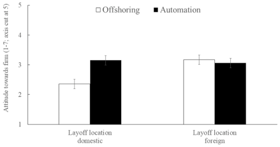

NOTE: figure/graphic rendered as an image from the PDF; its content is not machine-readable text. Caption (if any) follows as the next block.

12.52, *p <* .001, *d* ¼ −0.48, CI95% ¼ [−0.76, −0.20]). When the layoffs occurred in a foreign country, however, there were no significant differences between the offshor ing (vs. automation) condition in terms of firm attitude (*M*offsh. ¼ 3.17, SD ¼ 1.67 vs. *M*autom. ¼ 3.06, SD ¼ 1.39; *F* (1, 398) ¼ 0.22, *p* ¼ .637, *d* ¼ 0.07, CI95% ¼ [−0.21, 0.35]). The results of this study demonstrate that the negative effect of offshoring (vs. automation) is stronger when a firm laid off workers in a domestic (vs. foreign) location. This finding materializes even though our pretest revealed no significant differences in product quality perceptions. It is therefore unlikely that perceived differences in product quality can explain the observed effects of offshoring.

#### **STUDY 5: LOCATION OF THE FIRM HQ**

Study 5 has two aims. The first is to test our prediction that consumer reactions to offshoring are moderated by the location of the firm’s HQ (hypothesis 3). We argue that consumer reactions to offshoring are grounded in the social contracts between firms and members of their society. Consequently, these reactions should be more negative when the firm’s HQ is domestic rather than foreign, as domestic firms are presumed to have a stronger social con tract with domestic consumers and workers. To test this prediction, we contrast collective layoffs due to offshoring with collective layoffs due to declining demand, which is a frequent reason for collective layoffs (Landsman and Stremersch 2020; US Bureau of Labor Statistics 2012), and one that should involve weaker perceptions of social con tract violations (as the collective layoff can be attributed to external market forces). The second aim of study 5 is to

test our predicted process that the negative effect of off shoring is mediated by perceived social contract violations. We therefore directly measured consumer perceptions of the strength of social contract violations. The study was preregistered (https://aspredicted.org/kzrg-sw24.pdf).

#### Method

We recruited 1,002 UK consumers (*M*age ¼ 40 years, 53% female; Prolific) and randomly assigned them to one of four conditions in a 2 (layoff reason: offshoring vs. declining demand) × 2 (location of the HQ: domestic vs. foreign firm) between-participants design. All participants read the generic description of a large manufacturer of industrial goods (the same as in study 4) with its main pro duction location in the United Kingdom, the home country of the participants. To manipulate the location of the HQ, participants read that the HQ was either located in the United Kingdom (i.e., representing a domestic firm) or overseas (i.e., representing a foreign firm).

In the offshoring condition, participants read that the firm had recently decided to move its main production overseas. Participants further read that the firm planned to open a new production plant abroad and rely on foreign workers. In the declining demand condition, participants read that the firm had recently decided to keep its main production location in the United Kingdom. Participants further read that the firm plans to restructure its existing production plant in the United Kingdom due to a severe drop in sales. In all conditions, participants were informed that because of the firm’s restructuring, the firm would lay off 4,000 workers at its UK plant. To hold quality percep tions constant, participants in all conditions moreover read

**FIGURE 1**

INTERACTION BETWEEN LAYOFF REASON AND LAYOFF LOCATION

12 JOURNAL OF CONSUMER RESEARCH

Page 13

that the quality of the production will not change. As our dependent variable, we measured firm attitude as before (α ¼ 0.97). As our process variable, we subsequently meas ured the extent to which participants perceived the collec tive layoff as a social contract violation using three items (“The firm fails to fulfill an unwritten obligation to the UK community in return for the support it receives from the UK community,” “The firm is violating what it should do for the UK community in exchange for what the UK com munity is doing for it,” and “The firm is violating an unwritten agreement about what it should do for the UK community”; 1 ¼ strongly disagree, 7 ¼ strongly agree; α ¼ 0.93). We derived these three items based on the core elements of the definition of social contracts (Dunfee et al. 1999; Wempe 2008).

#### Results

A two-way ANOVA on firm attitude revealed a main effect of layoffs due to offshoring (vs. declining demand; *M*offsh. ¼ 2.36, SD ¼ 1.30 vs. *M*decl. dem. ¼ 3.39, SD ¼ 1.30; *F*(1, 998) ¼ 159.83, *p <* .001, η<sup>2</sup>¼ 0.14, CI95% ¼ [0.10, 0.18]). We observed no main effect of the firm’s HQ loca tion (*F*(1, 998) ¼ 0.41, *p* ¼ .523, η<sup>2</sup>¼ 0.00, CI95% ¼ [0.00, 0.01]). Crucially, and as preregistered, we found a signifi cant two-way interaction (*F*(1, 998) ¼ 18.76, *p <* .001, η<sup>2</sup>

¼ 0.02, CI95% ¼ [0.01, 0.04]; left panel of figure 2).

The negative effect of offshoring on firm attitude was significantly stronger when the firm’s HQ location was domestic (vs. foreign); that is, participants rated the off shoring firm significantly more negatively in the domestic (vs. foreign) HQ condition (*M*dom. ¼ 2.21, SD ¼ 1.26 vs. *M*for. ¼ 2.51, SD ¼ 1.33; *F*(1, 998) ¼ 6.83, *p* ¼ .009, *d* ¼ −0.23, CI95% ¼ [−0.41, −0.06]). In contrast, this pat tern reversed when collective layoffs were due to declining demand. Participants rated a firm with a domestic (vs.

foreign) HQ location significantly more positively when it laid off workers due to declining demand (*M*dom. ¼ 3.59, SD ¼ 1.26 vs. *M*for. ¼ 3.19, SD ¼ 1.31; *F*(1, 998) ¼ 12.33, *p <* .001, *d* ¼ 0.32, CI95% ¼ [0.14, 0.49]). While not cen tral to our theorizing, the latter simple effect is a replication of the well-established home country bias (Sharma 2011; Verlegh 2007), which, in the absence of a strong social contract violation, appears to be driving consumer attitudes even in the context of a collective layoff.

We found the same pattern of results for perceived social contract violations (layoff reason: *F*(1, 998) ¼ 124.82, *p <* .001, η<sup>2</sup>¼ 0.11, CI95% ¼ [0.08, 0.15]; interaction: *F*(1, 998) ¼ 43.44, *p <* .001, η<sup>2</sup>¼ 0.04, CI95% ¼ [0.02, 0.07]; see web appendix E for detailed analyses). As preregis tered, a moderated mediation analysis confirmed the medi ating role of perceived social contract violations (index: *b* ¼ −0.514, SE ¼ 0.09, CI95% ¼ [−0.68, −0.34]). The indirect effect of layoffs due to offshoring (vs. declining demand) on firm attitude through perceived social contract violations was significantly stronger when the firm was domestic (*b* ¼ −0.692, SE ¼ 0.07, CI95% ¼ [−0.83, −0.55]) versus foreign (*b* ¼ −0.179, SE ¼ 0.06, CI95% ¼ [−0.29, −0.07]; the two CIs do not overlap). The results thus support our theorizing. Following Pieters (2017), we examined the unconfoundedness and distinctiveness condi tions for moderated mediation (for a detailed discussion of the reliability condition, see web appendix E). A sensitivity analysis (Imai, Keele, and Yamamoto 2010) demonstrated that the moderated mediation effect would become insig nificant if omitted variables reduced its original magnitude by more than 85% (sensitivity parameter ρ ¼ −0.48; see web appendix E for details). This suggests that the original negative moderated mediation effect is relatively robust to the existence of unobserved confounders (Imai et al. 2010). A two-factor model with the respective measures for per ceived social contract violations and firm attitude on

**FIGURE 2**

INTERACTION BETWEEN FIRM HEADQUARTERS AND LAYOFF REASON

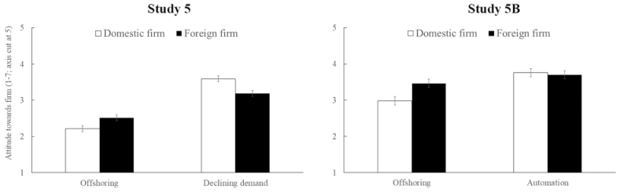

separate factors fitted significantly better than a one-factor model (χ<sup>2</sup>(1) ¼ 1981.67, *p <* .001). Both the mediator and the outcome passed the strict criterion test (perceived social contract violations AVE¼0.82; firm attitude AVE¼0.91; *R*<sup>2</sup>between latent mediator and outcome¼0.33). Thus, dis criminant validity for the mediator and outcome constructs can be accepted. Finally, we note that this study not only provides mediation evidence for our predicted process but also moderation evidence by manipulating an important antecedent of social contract violation (i.e., the firm’s HQ).

*Follow-up Study 5B.* We conducted an additional pre registered study, study 5B (*N* ¼ 1,066, *M*age ¼ 41 years, 52% female; MTurk; details reported in web appendix E; https://aspredicted.org/3gkv-ys6n.pdf) that aimed to (i) conceptually replicate the results of study 5 using a differ ent sample (i.e., US consumers) and a different control con dition (i.e., automation) and (ii) test whether the predicted effect can be explained by individuals’ ethnocentrism (α ¼ 0.95; Neuliep and McCroskey 1997) and patriotism (α ¼ 0.86; Federico, Golec, and Dial 2005), two accounts men tioned in previous literature as explanations of consumer reactions to offshoring (Durvasula and Lysonski 2008; Thelen et al. 2011). For example, individual differences in ethnocentrism or patriotism may amplify the effect of off shoring when a domestic company moves production off shore to benefit foreign workers. If so, then we would expect that ethnocentrism or patriotism moderate the inter action effect between the firm’s HQ and offshoring (Simonsohn 2019).

Consistent with the previous results and supporting hypothesis 3, we find that participants react more nega tively to collective layoffs due to offshoring (vs. automa tion) when the firm is domestic (vs. foreign; interaction: *F* (1, 1062) ¼ 5.57, *p* ¼ .018, η<sup>2</sup>¼ 0.01, CI95% ¼ [0.00, 0.02]; see right panel of figure 2). Moreover, we find that neither ethnocentrism nor patriotism significantly moder ated this significant two-way interaction effect between our two experimental factors (all three-way interactions were not significant; all *p*s *>* .192; see web appendix E for detailed analyses). This lack of a significant three-way interaction suggests that variations in ethnocentrism and patriotism are unlikely to explain why the negative effect of offshoring is stronger when the firm’s HQ is domestic (vs. foreign).

#### **STUDY 6: LOCATION OF THE FIRM’S**

#### **CUSTOMER BASE**

In study 6, we focus our attention on offshoring only and investigate whether consumers’ reactions to offshoring depend on the location of the customer base (hypothesis 4). Social contracts define implicit give-and-take relationships between firms and members of a given society, such as consumers. Consumers should therefore perceive firms to

violate the social contract more strongly when the majority of their customers is located in the firm’s home country rather than in a foreign country. This is because, in the for mer case, consumers “fulfill” their part of the give-and- take relationship. We again also test whether ethnocentrism and patriotism could serve as alternative explanations. The study was preregistered (https://aspredicted.org/p98g-y8p2. pdf).

#### Method

We recruited 763 UK consumers (*M*age ¼ 41 years, 64% female; Prolific) and randomly assigned them to one of three conditions (customer location: foreign vs. domestic vs. control) of an experiment using a between-participants design. All participants were introduced to the same UK- based firm as in study 2. In all conditions, participants read that the firm had decided to offshore jobs abroad and lay off 4,000 workers. Moreover, we added a short description of the customer base of the firm, which was our manipula tion. In the foreign customer location condition, partici pants read that more than 90% of the firm’s customers were not from the United Kingdom (i.e., not from the home country of the participants and the firm described). In the domestic customer location condition, participants read that more than 90% of the firm’s customers were from the United Kingdom. In the control condition, participants instead received no information about the firm’s customer base. We then measured participants’ attitude toward the firm (α ¼ 0.97), the extent to which participants perceived the collective layoffs as a social contract violation (α ¼ 0.91), and participants’ ethnocentrism (α ¼ 0.83) and patriotism (α ¼ 0.83) as before.

#### Results

An ANOVA on firm attitude produced a significant dif ference across conditions (*F*(2, 760) ¼ 33.82, *p <* .001, η<sup>2</sup>

¼ 0.08, CI95% ¼ [0.05, 0.12]). As preregistered, partici pants rated the offshoring firm less negatively in the for eign customer location condition (*M*for. ¼ 3.52, SD ¼ 1.48) than in the domestic customer location condition (*M*dom. ¼ 2.66, SD ¼ 1.44; *t*(760) ¼ 6.92, *p <* .001, *d* ¼ 0.59, CI95% ¼ [0.41, 0.77]) or the control condition, in which partici pants received no information about the location of cus tomers (*M*contr. ¼ 2.61, SD ¼ 1.30; *t*(760) ¼ 7.31, *p <* .001, *d* ¼ 0.66, CI95% ¼ [0.48, 0.83]). We found no significant difference between the two latter conditions (*t*(760) ¼ 0.37, *p* ¼ .708, *d* ¼ 0.03, CI95% ¼ [−0.14, 0.21]). The pat tern of results for perceived social contract violations was consistent (*M*for. ¼ 3.93, SD ¼ 1.60; *M*dom. ¼ 5.19, SD ¼ 1.33; *M*contr. ¼ 5.22, SD ¼ 1.24; *F*(2, 760) ¼ 71.50, *p <* .001, η<sup>2</sup>¼ 0.16, CI95% ¼ [0.11, 0.20]).

We next tested whether the effect of customer location on firm attitude is mediated by perceived social contract violations, adding participants’ ethnocentrism and

patriotism as covariates into the model. Controlling for these alternative explanations, this mediation model revealed that perceived social contract violations can explain why participants rated the offshoring firm less neg atively in the foreign customer location condition than in the domestic customer location condition (*b* ¼ −0.598, SE ¼ 0.08, CI95% ¼ [−0.75, −0.45]) or than in the control condition (*b* ¼ −0.608, SE ¼ 0.08, CI95% ¼ [−0.76, −0.45]). That is, participants perceived that offshoring vio lated the social contract less when most customers were foreign (*M*for. ¼ 3.93, SD ¼ 1.60) than when they were domestic (*M*dom. ¼ 5.19, SD ¼ 1.33; *t*(760) ¼ −10.21, *p <* .001, *d* ¼ −0.86, CI95% ¼ [−1.04, −0.68]) or when no information about the customer location was provided (*M*contr. ¼ 5.22, SD ¼ 1.24; *t*(760) ¼ −10.50, *p <* .001, *d* ¼ −0.91, CI95% ¼ [−1.09, −0.73]), which, in turn, drove participants’ attitude toward the offshoring firm. These results thus support our hypothesis 4, controlling for ethno centrism and patriotism. Moreover, including these alterna tive mechanisms helps to make the unconfoundedness condition for a meaningful mediation more plausible (Fiedler, Schott, and Meiser 2011). Sensitivity analyses demonstrated that the mediation findings presented in this study appear robust (ρs¼−0.47; Imai et al. 2010). Discriminant validity for the mediator and outcome con structs can be accepted (a two-factor model fitted signifi cantly better than a one-factor model; χ<sup>2</sup>(1) ¼ 1119.28, *p <* .001; AVEs ≥ 0.77; *R*<sup>2</sup>between latent mediator and out come ¼ 0.31; for a detailed discussion of the directionality, reliability, and power conditions, see web appendix E).

*Follow-up Study 6B.* Study 6B (*N* ¼ 120 UK consum ers; *M*age ¼ 38 years, 61% female; Prolific) used the same experimental stimuli as study 6 and two of its experimental conditions (customer location: foreign vs. domestic; between-subjects). We aimed to test whether our social contract account offers more explanatory power than, and is empirically distinct from, a social norm account to explain consumer reactions to offshoring. Social norms are conceptually related to social contracts (Elster 1989), but, unlike social norms, social contracts involve an implicit give-and-take relationship between exchange parties (Dunfee et al. 1999; Elster 1989). Based on this conceptual difference, and the core elements of the definition of social norms (Cialdini et al. 1990; Elster 1989), we measured per ceived social norm violations with three Likert items (“The firm is violating generally accepted standards of behavior in the UK,” “The firm does not conform with the typical behavior of UK firms,” and “The firm’s behavior is disap proved by most people in the UK”; 1 ¼ strongly disagree, 7 ¼ strongly agree; α ¼ 0.67). Consistent with our concep tual expectations, an exploratory factor analysis with prin cipal component analysis and varimax rotation produced a two-factor solution (web appendix E). The factor loading of one item of the social norms scale (“The firm’s behavior

is disapproved by most people in the UK”) was equal to the benchmark value of 0.50 (Hair et al. 2009). Repeating all analyses presented below without this item produced con sistent results (web appendix E).

Consistent with our previous findings, participants rated the offshoring firm less negatively when most customers were foreign (*M*for. ¼ 3.26, SD ¼ 1.37 vs. *M*dom. ¼ 2.58, SD ¼ 1.27; *t*(118) ¼ 2.82, *p* ¼ .006, *d* ¼ 0.52, CI95% ¼ [0.15, 0.88]) and perceived that it violated the social con tract less when most customers were foreign (*M*for. ¼ 4.16, SD ¼ 1.67 vs. *M*dom. ¼ 5.46, SD ¼ 1.10; *t*(118) ¼ −5.06, *p <* .001, *d* ¼ −0.92, CI95% ¼ [−1.30, −0.54]). In contrast, we found no difference in terms of social norm violation (*p* ¼ .781). A multiple mediation model revealed only a sig nificant mediation effect of perceived social contract viola tions (indirect effect: *b* ¼ −0.521, SE ¼ 0.18, CI95% ¼ [−0.87, −0.17]) but not of perceived social norm violations (indirect effect: *b* ¼ 0.002, SE ¼ 0.01, CI95% ¼ [−0.02, 0.02]). A sensitivity analysis with perceived social norm violations as a covariate demonstrated that the mediation findings appear relatively robust to unobserved confound ers (ρ ¼ −0.37). Perceived social contract and social norm violations and firm attitude passed the strict criterion test (AVE’s ≥ 0.50; *R*<sup>2</sup>between latent constructs ≤0.30). These results suggest that we can empirically distinguish between social contract violations and social norm viola tions, and that our social contract account is more effective in explaining the observed effect.

#### **GENERAL DISCUSSION**

Collective layoffs are a widespread phenomenon in Western societies and are often the result of firms’ efforts to reduce costs and increase efficiency. Such events tend to receive prominent media coverage and can have serious negative repercussions on how individuals think and feel about companies (Landsman and Stremersch 2020). However, prior consumer research has not provided a com prehensive account of consumer reactions to collective lay off decisions. One widely used strategy to increase efficiency is offshoring—laying off local workers and moving the production abroad—a practice that has sparked heated and controversial debates in the media and political arenas. In this research, we propose a theory based on social contract violations and examine why consumers are seemingly reacting more negatively to offshoring com pared to other efficiency-enhancing strategies that entail collective layoffs.

Across seven experimental studies on consumer responses (*N* ¼ 4,761), analyses of user-generated content on Reddit (*N* ¼ 29,045), and media reports on European collective layoffs (*N* ¼ 1,261), we consistently observe more negative responses when firms laid off workers due to offshoring than due to other efficiency-driven reasons such as automation, aligning with our first hypothesis.

These findings remain consistent across different partici pant populations, stimuli, measures, designs, and—keeping the number of domestic job losses constant—four different layoff reasons often related to a firm’s pursuit for greater efficiency and cost reduction: outsourcing, relocation, declining demand, and, most prominently, automation.

Our experimental studies provide evidence for the role of perceived social contract violations in explaining our findings, utilizing mediation, moderation, and moderated mediation approaches. As social contracts imply a recipro cal relationship between firms and members of their soci ety (e.g., consumers), we theorized that both firm-related and consumer-related factors should affect consumer per ceptions of social contract violations. In line with this rea soning, we find that the negative effect of offshoring is stronger when offshoring affects workers in the consumers’ home (vs. foreign) country (study 4; hypothesis 2), when the offshoring firm is domestic (vs. foreign; studies 5 and 5B; hypothesis 3), and when most customers are domestic (vs. foreign; studies 6 and 6B, hypothesis 4). Below, we discuss the theoretical and practical implications of the studies, as well as highlight limitations and future research opportunities.

#### Theoretical and Practical Implications

First, our study introduces a framework for understand ing consumer responses to offshoring—one of the most controversial and politicized aspects of globalization (Owen 2017). Our theory hinges on the idea that when a firm lays off workers and moves production to a foreign country, it breaches a fundamental element of the give- and-take relationship inherent in the social contract: the normative expectation that firms (should) support members of their society. Our account allows predictions that extend beyond existing theories; it also explains greater variance in consumer attitudes toward offshoring firms than other accounts based, for example, on ethnocentrism or product quality. As such, it provides a comprehensive theory to enhance our understanding of the factors affecting con sumer responses to collective layoffs and elucidates why and when consumers react more negatively to offshoring than to other efficiency-enhancing strategies. In addition, our research delineates the unique impact of offshoring, distinguishing it from the general effects of layoffs—a dis tinction not allowed by the design of previous research (Grappi et al. 2013).

Second, our research advances the literature on social contracts by shedding light on the formation and violation of social contracts between firms and consumers. In doing so, this work advances existing research in marketing (Malhotra et al. 2017; Montgomery et al. 2018), which has mainly focused on how consumers react to instances where their psychological contracts with brands are violated (e.g., when brands unexpectedly increase prices). Our research

suggests that the country of origin of a firm and of a firm’s customer base are important elements in the formation of social contracts, an understudied aspect in social contract theory (Thompson and Hart 2006). These new insights may in turn inform phenomena beyond offshoring. For instance, consumer responses to brand transgressions may depend on firm-level factors that strengthen social contract percep tions, such as a firm’s historical ties to a particular society.

Third, our research contributes to the field of lay eco nomics (Bhattacharjee et al. 2017; Boyer and Petersen 2017) by shedding light on how laypeople perceive the causes of collective layoffs. While these perceptions shape political beliefs and policy reactions, they remain currently a neglected topic. For example, prior literature shows that people react more negatively to globalization than to tech nological change, of which offshoring and automation are the most visible manifestations, even though the technolog ical change has a more significant impact on labor markets (Rodrik 2018). This disparity has been linked with country- specific attitudes (e.g., patriotism or ethnocentrism). Our social contract account offers a deeper understanding of why consumers react differently to layoffs caused by off shoring versus automation and when these effects materialize.

Practically, our work also informs the managerial dis course on the consequences of firms’ collective layoff deci sions. Prior research has mainly focused on the general effects of collective layoffs on sales and marketing mix elasticities (Landsman and Stremersch 2020) and firm rep utation (Love and Kraatz 2009). Our research advances this work by highlighting the unique consumer responses to off shoring, indicating that managers should view offshoring through a different lens than other forms of collective lay offs. Given that collective layoff decisions frequently appear in the media (study 3B), our findings imply that managers should not only consider supply-side effects of offshoring (Kotabe and Mudambi 2009) but also poten tially negative demand-side effects.

#### Limitations and Future Research Directions

Our research has several limitations that offer avenues for future research. First, the field data in studies 3A and 3B, which cover a wide range of online consumer responses and media coverage, rely on correlational analy ses, limiting the ability to draw causal inferences. In all other studies, we tested the effect of offshoring experimen tally, using both consequential and attitudinal measures. Future research could replicate these findings from highly controlled environments in real-world settings and assess whether consumer reactions also influence downstream behaviors, such as consumer boycotts (Klein et al. 2004).

Second, we compared reactions to offshoring to other common types of layoffs that displace local labor: declin ing demand, automation, relocation, and outsourcing (the

latter two allowing similar jobs to remain in the country). Each type of collective layoffs has idiosyncratic character istics, and there is no “natural” control condition for off shoring; yet, comparisons of these other forms of layoffs with offshoring revealed consistent patterns of results. Moreover, studies 5, 5B, 6, and 6B allow for a test of our social contract account that does not rely on comparing off shoring to another reason for layoffs, circumventing this issue. Also, we did not differentiate firm motivations for offshoring (e.g., cost reduction or access to talent; Grappi, Romani, and Bagozzi 2015). If some motivations are per ceived as a less egregious violation of the social contract, offshoring firms would have an incentive to ensure the pub lic is aware of it. Moreover, studies 5 and 5B manipulated the firm’s country of origin by manipulating the firm’s HQ location. While this connection is well-grounded in the existing literature (Johansson, Douglas, and Nonaka 1985; Samiee, Shimp, and Sharma 2005), there are instances where it may be weaker (e.g., when the HQ location is related to tax considerations) or where it may be stronger (e.g., when the HQ location is related to historical factors); this may, in turn, lead to weaker or stronger reciprocity expectations emanating from the social contract. Future research could systematically explore these differences.

Third, our work did not investigate how perceptions of social contract violations depend on the economic rationale behind a firm’s offshoring decision. Based on our social contract account, however, it is conceivable that consumers react less negatively to offshoring when they perceive it as a necessary response to an unfavorable business environ ment (e.g., demand-side changes) or external market pres sures, making the perceived violation of the social contract more acceptable. Additionally, future studies could exam ine whether firms can mitigate the breach of the social con tract caused by offshoring. Our framework suggests that offering various forms of compensation to society may help reduce perceptions of social contract violations (e.g., investing in community development) and thus attenuate the negative impact of offshoring.

Fourth, we derived our hypotheses from the concept of social contracts at the firm level, which allowed us to iden tify key moderators of the negative effect of offshoring, including firm characteristics (e.g., the firm’s HQ location) and consumer characteristics (e.g., the firm’s customer base location). Future studies could build on our findings by examining the impact of social contract violations at dif ferent hierarchical levels. For instance, future research might investigate whether consumers respond differently when a social contract is violated by an entire industry compared to a single firm (e.g., if most or all firms in an industry decide to offshore production). Additionally, future work may investigate whether perceived social con tract violations vary by industry type (e.g., manufacturing vs. healthcare) or workforce type (e.g., blue-collar vs. white-collar). Exploring these questions could provide a

more nuanced understanding of the perceptions of social contract violations.

Fifth, future research may explore perceived social con tract violations arising from automation. Unlike offshoring, automation does not provide employment opportunities to a foreign society at the expense of the domestic society. Consequently, consumers may initially view automation as less of a social contract violation, as the social contract has traditionally been understood as an agreement among human members within a specific society or nation-state (Donaldson 1982; Hsieh 2015; Rawls 2009). However, advances in robotics increasingly enable firms to use machines with humanlike features and behaviors, allowing them to replace human workers across various industries (Kim, Schmitt, and Thalmann 2019; Schmitt 2019; van Doorn et al. 2017). As robots become more humanlike, they may blur the boundaries of what is considered part of the social contract (Duffy 2003). For instance, the use of humanlike machines could trigger negative social compari son processes where humans may perceive themselves as being collectively displaced or devalued by non-human entities (Granulo, Fuchs, and Puntoni 2019). Accordingly, consumers may perceive the use of automation as affecting humanity’s collective social contract. We thus encourage future research to investigate whether implicit assumptions about the social contract are indeed human-centered and to explore how automation (e.g., robotics) may expand or challenge this framework.

Sixth, our studies did not examine how specific charac teristics of the country to which production is offshored affect consumer reactions, which offers opportunities for future research. Related to this point, one could argue that the observed stronger negative reactions toward domestic (vs. foreign) offshoring firms could be influenced by the belief that foreign firms simply “return” jobs to their home countries. To address this possibility, we conducted an additional study (*N* ¼ 401) in which we explicitly named the country to which a firm offshores (see web appendix E for details). This study produced consistent results (interac tion effect: *p <* .001). Nevertheless, we acknowledge that the offshoring destination might moderate the effect of off shoring based on variables such as the similarity of the countries, the relative level of economic development, and specific historical factors (e.g., diplomatic relations). We therefore encourage future research to explore contingen cies in consumer reactions to offshoring decisions based on contextual variables like these. In a similar vein, and more fundamentally, it is possible that socioeconomic and cul tural differences across countries might systematically affect how consumers perceive social contracts and their formation, an important topic for future research.

Seventh, this work argued and empirically demonstrated that factors on both the firm side (e.g., the origin of the off shoring firm) and the society side (e.g., the society affected by offshoring) can weaken the perceived strength of the

social contract, thereby moderating consumer reactions to offshoring by reducing perceptions of social contract viola tions. Future studies are needed to disentangle the strength of a social contract from the magnitude of its violation. Moreover, this research examined how social contract vio lations drive consumer reactions to offshoring and ruled out several alternative theoretical accounts. To gain insights into other processes, we conducted yet another study (*N* ¼ 406) aimed at addressing the competing accounts of product quality, authenticity, and attitude toward technology (see web appendix E for details). This study confirmed that perceived social contract violations can explain consumer reactions to offshoring, controlling for alternative mechanisms; in addition, this study revealed that these reactions are a multiply determined phenom enon: perceived firm authenticity and product quality are also significant mediators. Additional research is needed to understand the varied psychological reactions to collective layoffs and the conditions when they are more likely to drive consumer behavior.

Finally, future research could investigate how consum ers’ perceptions of collective layoff decisions depend on a sense of community. For example, German consumers may view a firm moving production from Germany to the Netherlands more negatively if they feel a strong sense of community at the national level (e.g., if they strongly iden tify themselves as Germans) rather than at the supra- national level (e.g., if they identify themselves as Europeans). Additionally, our social contract framework suggests that relocating jobs within a country could trigger similar negative effects as relocating jobs abroad. This might be particularly the case in countries with weaker internal cohesion. For example, a Northern Italian company relocating production to Southern Italy could be seen as a breach of the social contract, especially in areas with dis tinct regional identities. Investigating the circumstances under which domestic job relocations are perceived as social contract violations presents an important avenue for future research.

#### **DATA COLLECTION STATEMENT**

The first author collected the data for study 1 in the spring of 2023 on MTurk (US participants). We preregis tered the hypotheses and study characteristics of study 1 (https://aspredicted.org/c4kz-vhym.pdf). The first author collected the data for study 2 in the spring of 2020 on Prolific (UK participants). We preregistered the hypotheses and study characteristics of study 2 (https://aspredicted.org/ bfqc-k77k.pdf). The first author collected the data for study 3A in two steps in the summer of 2022. First, the author wrote a code that searched for Reddit posts that contained a set of pre-specified search terms. Then, two research assis tants blind to the research question independently catego rized each post based on pre-specified criteria. We

preregistered the code, hypothesis, data collection proce dure, and data analysis plan of study 3 (https://aspredicted. org/9zp4-422q.pdf). The first author collected the data for study 3B in the spring of 2018 from the EU agency Eurofound. The first author collected the data for study 4 in the spring of 2023 on MTurk (US participants). The first author collected the data for study 5 in the spring of 2023 on Prolific (UK participants). We preregistered the hypoth eses and study characteristics of study 5 (https://aspre dicted.org/kzrg-sw24.pdf). The first author collected the data for study 5B in the spring of 2023 on MTurk (US par ticipants). We preregistered the hypotheses and study char acteristics of study 5B (https://aspredicted.org/3gkv-ys6n. pdf). The first author collected the data for study 6 in the spring of 2023 on Prolific (UK participants). We preregis tered the hypotheses and study characteristics of study 6 (https://aspredicted.org/p98g-y8p2.pdf). The first author collected the data for study 6B in the spring of 2023 on Prolific (UK participants). The first author collected the data for supplementary study S1 in the spring of 2023 on Prolific (UK participants). The first author collected the data for supplementary study S2 in the spring of 2023 on Prolific (UK participants). The authors collectively designed the studies. The first and second authors analyzed the data and discussed the results with the other two authors. The data are currently stored on and openly avail able in the Open Science Framework (https://osf.io/9vjt5/).

#### **REFERENCES**

Aaker, David A. and Robert Jacobson (2001), “The Value

Relevance of Brand Attitude in High-Technology Markets,” *Journal of Marketing Research*, 38 (4), 485–93. Acemoglu, Daron and Pascual Restrepo (2020), “Robots and Jobs:

Evidence from US Labor Markets,” *Journal of Political Economy*, 128 (6), 2188–244. Anderson, Benedict (2006), *Imagined Communities: Reflections*

*on the Origin and Spread of Nationalism*, London, UK: Verso Books. Balliet, Daniel, Junhui Wu, and Carsten K. W. De Dreu (2014),

“Ingroup Favoritism in Cooperation: A Meta-Analysis,” *Psychological Bulletin*, 140 (6), 1556–81. Becker-Olsen, Karen L. (2003), “And Now, a Word from Our

Sponsor—A Look at the Effects of Sponsored Content and Banner Advertising,” *Journal of Advertising*, 32 (2), 17–32. Bharadwaj, Neeraj and Anne L. Roggeveen (2008), “The Impact

of Offshored and Outsourced Call Service Centers on Customer Appraisals,” *Marketing Letters*, 19 (1), 13–23. Bhattacharjee, Amit, Jason Dana, and Jonathan Baron (2017),

“Anti-Profit Beliefs: How People Neglect the Societal Benefits of Profit,” *Journal of Personality and Social Psychology*, 113 (5), 671–96. Biden, Joe (2020), “The Biden-Harris Plan to Fight for Workers by

Delivering on Buy America and Make It in America,” Last Accessed September 16, 2024. https://joebiden.com/wp-con tent/uploads/2020/09/Buy-America-fact-sheet.pdf. Boegershausen, Johannes, Hannes Datta, Abhishek Borah, and

Andrew T. Stephen (2022), “Fields of Gold: Scraping Web

Data for Marketing Insights,” *Journal of Marketing*, 86 (5), 1–20. Boyer, Pascal and Michael Bang Petersen (2017), “Folk-

Economic Beliefs: An Evolutionary Cognitive Model,” *The Behavioral and Brain Sciences*, 41, e158. Bretscher, Lorenzo (2023), “From Local to Global: Offshoring

and Asset Prices,” *Management Science*, 69 (3), 1420–48. Brown, Sharon P. and Jeremy Siegel (2004), “Mass Layoff

Statistics Data in The United States and Domestic and Overseas Relocation,” US Department of Labor, Bureau of Labor Statistics, paper presented at EU-US Seminar on “Offshoring of Services in ICT and Related Services.” Chan, Kalok, Vicentiu Covrig, and Lilian Ng (2005), “What

Determines the Domestic Bias and Foreign Bias? Evidence from Mutual Fund Equity Allocations Worldwide,” *The Journal of Finance*, 60 (3), 1495–534. Cialdini, Robert B., Raymond R. Reno, and Carl A. Kallgren

(1990), “A Focus Theory of Normative Conduct: Recycling the Concept of Norms to Reduce Littering in Public Places,” *Journal of Personality and Social Psychology*, 58 (6), 1015–26. Contractor, Farok J., Vikas Kumar, Sumit K. Kundu, and Torben

Pedersen (2010), “Reconceptualizing the Firm in a World of Outsourcing and Offshoring: The Organizational and Geographical Relocation of High-Value Company Functions,” *Journal of Management Studies*, 47 (8), 1417–33. Dalton, Russell J. (2021), “National/European Identities and

Political Alignments,” *European Union Politics*, 22 (2), 340–50. Datta, Deepak K., James P. Guthrie, Dynah Basuil, and Alankrita

Pandey (2010), “Causes and Effects of Employee Downsizing: A Review and Synthesis,” *Journal of Management*, 36 (1), 281–348. Di Gregorio, Dante, Martina Musteen, and Douglas E. Thomas

(2009), “Offshore Outsourcing as a Source of International Competitiveness for SMEs,” *Journal of International Business Studies*, 40 (6), 969–88. Donaldson, Thomas (1982), *Corporations and Morality*, Englewood Cliffs, NJ: Prentice-Hall. Duffy, Brian R. (2003), “Anthropomorphism and the Social

Robot,” *Robotics and Autonomous Systems*, 42 (3–4), 177–90. Dunfee, Thomas W., N. Craig Smith, and William T. Ross Jr.

(1999), “Social Contracts and Marketing Ethics,” *Journal of Marketing*, 63 (3), 14–32. Durvasula, Srinivas and Steven Lysonski (2008), “How Offshore

Outsourcing Is Perceived: Why Do Some Consumers Feel More Threatened?,” *Journal of International Consumer Marketing*, 21 (1), 17–33. Elster, Jon (1989), “Social Norms and Economic Theory,” *Journal*

*of Economic Perspectives*, 3 (4), 99–117. Erikson, Robert S. and Kent L. Tedin (2015), *American Public*

*Opinion: Its Origins, Content and Impact*, 9th ed., New York, NY: Routledge. Esses, Victoria M., John F. Dovidio, Lynne M. Jackson, and

Tamara L. Armstrong (2001), “The Immigration Dilemma: The Role of Perceived Group Competition, Ethnic Prejudice, and National Identity,” *Journal of Social Issues*, 57 (3), 389–412. Eurofound (2018), “European Restructuring Monitor,” Last

Accessed September 16, 2024. https://www.eurofound. europa.eu/en/resources/european-restructuring-monitor.

Falk, Armin and Urs Fischbacher (2006), “A Theory of

Reciprocity,” *Games and Economic Behavior*, 54 (2), 293–315. Farrell, Diana (2005), “Offshoring: Value Creation through

Economic Change,” *Journal of Management Studies*, 42 (3), 675–83. Fazio, Russell and Richard E. Petty (2008), *Attitudes: Their*

*Structure, Function, and Consequences*, Hove, UK: Psychology Press. Federico, Christopher M., Agnieszka Golec, and Jessica L. Dial

(2005), “The Relationship between the Need for Closure and Support for Military Action against Iraq: Moderating Effects of National Attachment,” *Personality & Social Psychology Bulletin*, 31 (5), 621–32. Fiedler, Klaus, Malte Schott, and Thorsten Meiser (2011), “What

Mediation Analysis Can (Not) Do,” *Journal of Experimental Social Psychology*, 47 (6), 1231–6. Frey, Carl Benedikt (2019), *The Technology Trap: Capital, Labor,*

*and Power in the Age of Automation*, Princeton, NJ: University Press. Gellner, Ernest (2008), *Nations and Nationalism*, Ithaca, NY:

Cornell University Press. Gelman, Andrew and Jennifer Hill (2006), *Data Analysis Using*

*Regression and Multilevel/Hierarchical Models*, Cambridge, UK: Cambridge University Press. Goldschmidt, Deborah and Johannes F. Schmieder (2017), “The

Rise of Domestic Outsourcing and the Evolution of the German Wage Structure,” *The Quarterly Journal of Economics*, 132 (3), 1165–217. Gouldner, Alvin W. (1960), “The Norm of Reciprocity: A

Preliminary Statement,” *American Sociological Review*, 25 (2), 161–78. Granulo, Armin, Christoph Fuchs, and Stefano Puntoni (2019),

“Psychological Reactions to Human versus Robotic Job Replacement,” *Nature Human Behaviour*, 3 (10), 1062–9. Grappi, Silvia, Simona Romani, and Richard P. Bagozzi (2013),

“The Effects of Company Offshoring Strategies on Consumer Responses,” *Journal of the Academy of Marketing Science*, 41 (6), 683–704. Grappi, Silvia, Simona Romani, and Richard P. Bagozzi (2015),

“Consumer Responses to Corporate Offshoring Practices,” *Management Decision*, 53 (3), 698–712. Guo, Lin, Thomas W. Gruen, and Chuanyi Tang (2017), “Seeing

Relationships through the Lens of Psychological Contracts: The Structure of Consumer Service Relationships,” *Journal of the Academy of Marketing Science*, 45 (3), 357–76. Hair, Joseph F., William Black, Barry Babin, and Rolph Anderson

(2009), *Multivariate Data Analysis*, London, UK: Prentice Hall. Haller, H. Brandon and Helmut Norpoth (1997), “Reality Bites:

News Exposure and Economic Opinion,” *Public Opinion Quarterly*, 61 (4), 555–75. Harari, Yuval Noah (2014), *Sapiens: A Brief History of*

*Humankind*, New York, NY: Random House. Hobbes, Thomas (1998), *On the Citizen*, Cambridge, UK:

Cambridge University Press. Hopkins, Daniel J., Eunji Kim, and Soojong Kim (2017), “Does

Newspaper Coverage Influence or Reflect Public Perceptions of the Economy?,” *Research & Politics*, 4 (4), 112–27. Hsieh, Nien-h^e (2015), “The Social Contract Model of Corporate

Purpose and Responsibility,” *Business Ethics Quarterly*, 25 (04), 433–60.

Huddy, Leonie and Nadia Khatib (2007), “American Patriotism,

National Identity, and Political Involvement,” *American Journal of Political Science*, 51 (1), 63–77. Hutto, Clayton J. and Eric Gilbert (2014), “VADER: A

Parsimonious Rule-Based Model for Sentiment Analysis of Social Media Text,” paper presented at the Eighth International AAAI Conference on Weblogs and Social Media, Ann Arbor, MI, USA. Imai, Kosuke, Luke Keele, and Teppei Yamamoto (2010),

“Identification, Inference and Sensitivity Analysis for Causal Mediation Effects,” *Statistical Science*, 25 (1), 51–71. Johansson, Johny K., Susan P. Douglas, and Ikujiro Nonaka

(1985), “Assessing the Impact of Country of Origin on Product Evaluations: A New Methodological Perspective,” *Journal of Marketing Research*, 22 (4), 388–96. Kahneman, Daniel, Jack L. Knetsch, and Richard H. Thaler

(1986), “Fairness as a Constraint on Profit Seeking: Entitlements in the Market,” *American Economic Review*, 76 (4), 728–41. Kim, Sang-Yeal, Bernd H. Schmitt, and Nadia M. Thalmann

(2019), “Eliza in the Uncanny Valley: Anthropomorphizing Consumer Robots Increases Their Perceived Warmth but Decreases Liking,” *Marketing Letters*, 30 (1), 1–12. King, Eden B., Jennifer L. Knight, and Michelle R. Hebl (2010),

“The Influence of Economic Conditions on Aspects of Stigmatization,” *Journal of Social Issues*, 66 (3), 446–60. Klein, Jill Gabrielle, N. Craig Smith, and Andrew John (2004),

“Why We Boycott: Consumer Motivations for Boycott Participation,” *Journal of Marketing*, 68 (3), 92–109. Kotabe, Masaaki and Ram Mudambi (2009), “Global Sourcing

and Value Creation: Opportunities and Challenges,” *Journal of International Management*, 15 (2), 121–5. Landsman, Vardit and Stefan Stremersch (2020), “The

Commercial Consequences of Collective Layoffs: Close the Plant, Lose the Brand?,” *Journal of Marketing*, 84 (3), 122–41. Lebrous, Michel (2017), “Reddit: Managing the ‘Front Page of the

Internet,’” *Digital Innovation and Transformation*, Last Accessed September 16, 2024. https://digital.hbs.edu/plat form-digit/submission/reddit-managing-the-front-page-of- the-internet/. Leisinger, Klaus M. (2005), “The Corporate Social Responsibility

of the Pharmaceutical Industry: Idealism Without Illusion and Realism Without Resignation,” *Business Ethics Quarterly: The Journal of the Society for Business Ethics*, 15 (4), 577–94. Love, E. Geoffrey and Matthew Kraatz (2009), “Character,

Conformity, or the Bottom Line? How and Why Downsizing Affected Corporate Reputation,” *Academy of Management Journal*, 52 (2), 314–35. Malhotra, Neeru, Sunil Sahadev, and Keyoor Purani (2017),

“Psychological Contract Violation and Customer Intention to Reuse Online Retailers: Exploring Mediating and Moderating Mechanisms,” *Journal of Business Research*, 75, 17–28. Margalit, Yotam (2011), “Costly Jobs: Trade-Related Layoffs,

Government Compensation, and Voting in US Elections,” *American Political Science Review*, 105 (1), 166–88. Mead, Nicole L., Lawrence E. Williams, Yunqian Fiona Tian, and

Hanieh Naemi (2024), “The Belief in the Social Contract Predicts Consumer Preferences and System-Level Policy Support.” https://doi.org/10.21203/rs.3.rs-5159867/v1

Meyvis, Tom and Stijn M. J. Van Osselaer (2018), “Increasing the

Power of Your Study by Increasing the Effect Size,” *Journal of Consumer Research*, 44 (5), 1157–73. Molm, Linda D. (2010), “The Structure of Reciprocity,” *Social*

*Psychology Quarterly*, 73 (2), 119–31. Montgomery, Nicole Votolato, Sekar Raju, Kalpesh Kaushik

Desai, and H. Rao Unnava (2018), “When Good Consumers Turn Bad: Psychological Contract Breach in Committed Brand Relationships,” *Journal of Consumer Psychology*, 28 (3), 437–49. Neiman, Paul (2013), “A Social Contract for International

Business Ethics,” *Journal of Business Ethics*, 114 (1), 75–90. Neuliep, James W. and James C. McCroskey (1997), “The

Development of a US and Generalized Ethnocentrism Scale,” *Communication Research Reports*, 14 (4), 385–98. Nieto, Marıa Jesus and Alicia Rodrıguez (2011), “Offshoring of

R&D: Looking Abroad to Improve Innovation Performance,” *Journal of International Business Studies*, 42 (3), 345–61. Nussbaum, Martha C. (2004), “Beyond the Social Contract:

Capabilities and Global Justice. An Olaf Palme Lecture, Delivered in Oxford on 19 June 2003,” *Oxford Development Studies*, 32 (1), 3–18. Owen, Erica (2017), “Exposure to Offshoring and the Politics of

Trade Liberalization: Debate and Votes on Free Trade Agreements in the US House of Representatives, 2001- 2006,” *International Studies Quarterly*, 61 (2), 297–311. Pieters, Rik (2017), “Meaningful Mediation Analysis: Plausible

Causal Inference and Informative Communication,” *Journal of Consumer Research*, 44 (3), 692–716. Rawls, John (2009), *A Theory of Justice*, Cambridge, MA:

Harvard University Press. Rodrik, Dani (2018), “Populism and the Economics of

Globalization,” *Journal of International Business Policy*, 1 (1–2), 12–33. Rousseau, Denise M. (1989), “Psychological and Implied

Contracts in Organizations,” *Employee Responsibilities and Rights Journal*, 2 (2), 121–39. Rousseau, Jean-Jacques (1997), *The Social Contract*, Ware, UK:

Wordsworth Editions. Samiee, Saeed, Terence A. Shimp, and Subhash Sharma (2005),

“Brand Origin Recognition Accuracy: Its Antecedents and Consumers’ Cognitive Limitations,” *Journal of International Business Studies*, 36 (4), 379–97. Schmitt, Bernd (2019), “From Atoms to Bits and Back: A

Research Curation on Digital Technology and Agenda for Future Research,” *Journal of Consumer Research*, 46 (4), 825–32. Shackelford, Todd K. and David M. Buss (1996), “Betrayal in

Mateships, Friendships, and Coalitions,” *Personality and Social Psychology Bulletin*, 22 (11), 1151–64. Sharma, Piyush (2011), “Country of Origin Effects in Developed

and Emerging Markets: Exploring the Contrasting Roles of Materialism and Value Consciousness,” *Journal of International Business Studies*, 42 (2), 285–306. Simonsohn, Uri (2019), “Interaction Effects Need Interaction

Controls,” *Blog post on Datacolada*, Last Accessed September 16, 2024. https://datacolada.org/80. Soroka, Stuart N., Dominik A. Stecula, and Christopher Wlezien

(2015), “It’s (Change in) the (Future) Economy, Stupid: Economic Indicators, the Media, and Public Opinion,” *American Journal of Political Science*, 59 (2), 457–74. St€abler, Sebastian, Alexander Himme, Alexander Edeling, and

Marco Backhaus (2023), “How Firm Communication Affects

the Impact of Layoff Announcements on Brand Strength over Time,” *International Journal of Research in Marketing*, 40 (3), 700–23. Stefaniak, Anna, Robyn K. Mallett, and Michael J. A. Wohl

(2020), “Zero-Sum Beliefs Shape Advantaged Allies’ Support for Collective Action,” *European Journal of Social Psychology*, 50 (6), 1259–75. Thelen, Shawn T., Boonghee Yoo, and Vincent P. Magnini (2011),

“An Examination of Consumer Sentiment Toward Offshored Services,” *Journal of the Academy of Marketing Science*, 39 (2), 270–89. Thompson, Jeffery A. and David W. Hart (2006), “Psychological

Contracts: A Nano-Level Perspective on Social Contract Theory,” *Journal of Business Ethics*, 68 (3), 229–41. Trivers, Robert L. (1971), “The Evolution of Reciprocal

Altruism,” *The Quarterly Review of Biology*, 46 (1), 35–57. US Bureau of Labor Statistics (2012), *Extended Mass Layoffs in*

*2012*, BLS Report 1043, September 2013. Van Doorn, Jenny, Martin Mende, Stephanie M. Noble, James

Hulland, Amy L. Ostrom, Dhruv Grewal, and J. Andrew

Petersen (2017), “Domo Arigato Mr Roboto: Emergence of Automated Social Presence in Organizational Frontlines and Customers’ Service Experiences,” *Journal of Service Research*, 20 (1), 43–58. Verlegh, Peeter W. J. (2007), “Home Country Bias in Product

Evaluation: The Complementary Roles of Economic and Socio-Psychological Motives,” *Journal of International Business Studies*, 38 (3), 361–73. Wempe, Ben (2008), “Four Design Criteria for Any Future

Contractarian Theory of Business Ethics,” *Journal of Business Ethics*, 81 (3), 697–714. Whitaker, Jonathan, Mayuram S. Krishnan, and Claes Fornell

(2006), “Does Offshoring Impact Customer Satisfaction?,” paper presented at the twelth *AMCIS 2006* Proceedings*,* Acapulco, Guerrero, Mexico, 394. Wolf, Holger C. (2000), “Intranational Home Bias in Trade,”

*Review of Economics and Statistics*, 82 (4), 555–63. Yamagishi, Toshio and Toko Kiyonari (2000), “The Group as the

Container of Generalized Reciprocity,” *Social Psychology Quarterly*, 63 (2), 116–32.

© The Author(s) 2025. Published by Oxford University Press on behalf of Journal of Consumer Research, Inc. This is an Open Access article distributed under the terms of the Creative Commons Attribution License (https://creativecommons.org/licenses/by/4.0/), which permits unrestricted reuse, distribution, and reproduction in any medium, provided the original work is properly cited. Journal of Consumer Research, 2025, 00, 1–21 https://doi.org/10.1093/jcr/ucaf001 Article